# Attrition Analyis

### Rates

- It is unclear what these are, however they do not appear strongly related to each other or have consistent trends with Attrition.
- Due to a lack of explainability, these will be left out of any further analysis unless a better understanding of what these represent is provided
  - Including in analysis causes risk since it is hard to say if there are any potential data integrity issues with the distributions

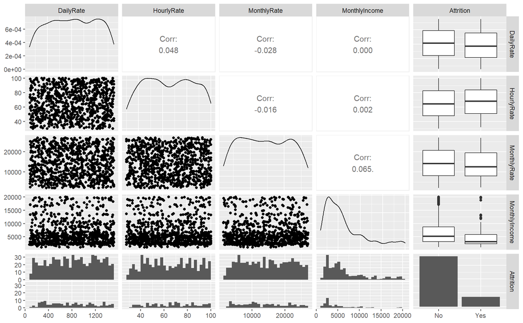

```r
#ggally with rates to get a better idea what relationship is or is not
hrdf %>% select(DailyRate, HourlyRate, MonthlyRate, MonthlyIncome, Attrition) %>% ggpairs()
```

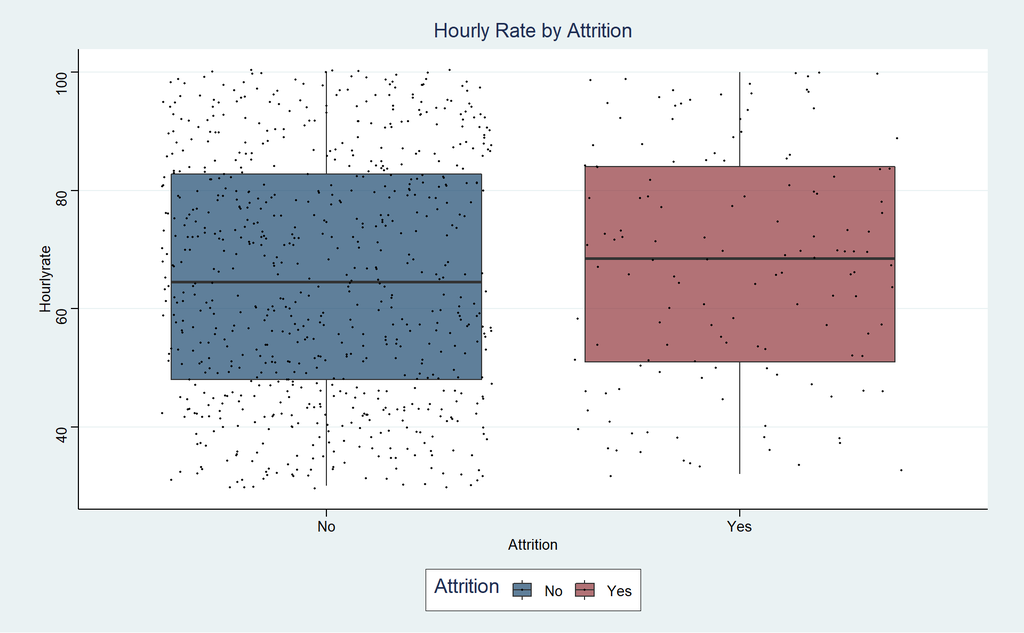

```r
box_plot_check(HourlyRate, Attrition, "Hourly Rate by Attrition")
```

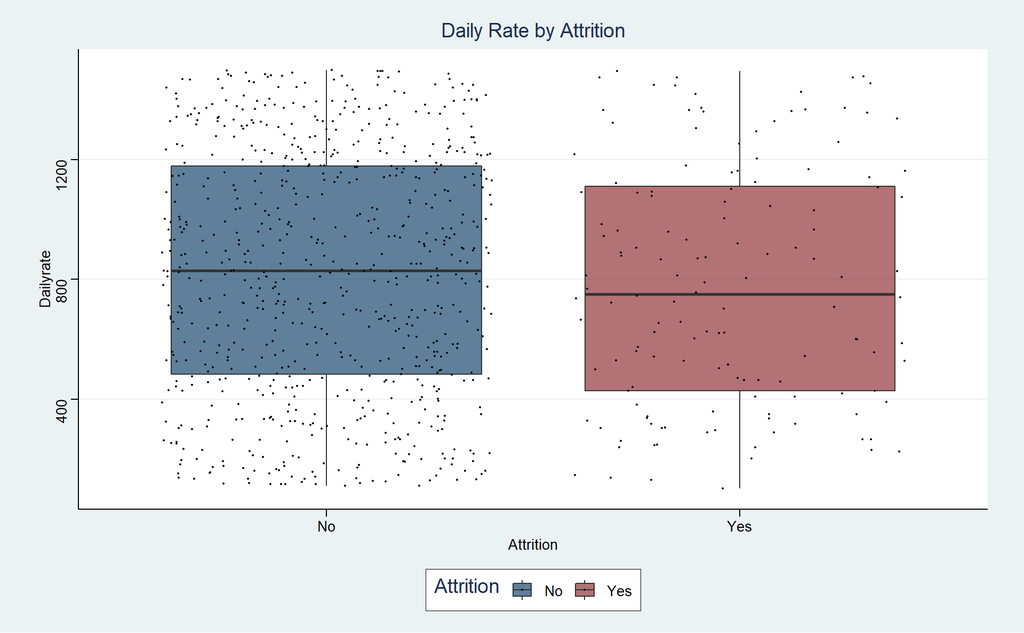

```r
box_plot_check(DailyRate, Attrition, "Daily Rate by Attrition")
```

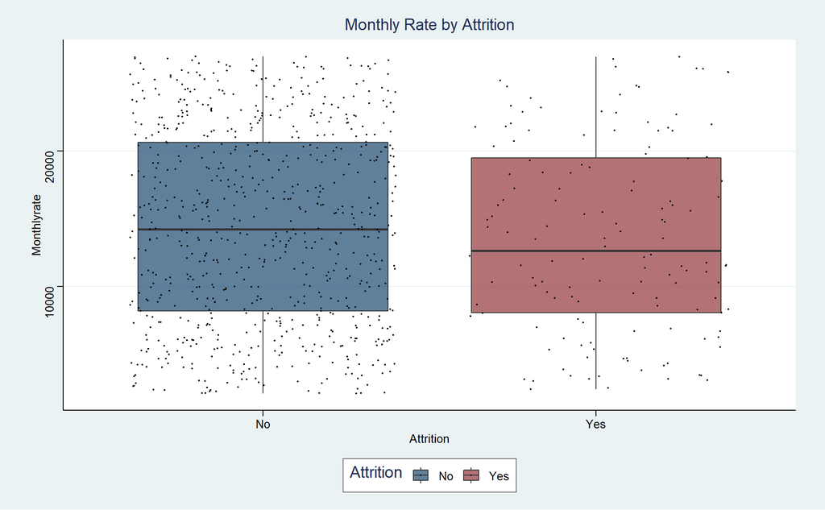

```r
box_plot_check(MonthlyRate, Attrition, "Monthly Rate by Attrition")
```

### Satisfaction

- Environment satisfaction appears to have consistent turnover at a rating of 2 or more. Those with a rating of 1 have quite a higher turnover.
- Job satisfaction has a more downward trend at each level, and those with a 4 have significantly less turnover than the other 3 ratings.
- Relationship satisfaction has a less consistent trend, although those with a rating of 1 have a more significant turnover than the other 3.
- Low work life balance has more than double turnover rate than other groups, fairly low count though. Job Involvement has similar pattern.

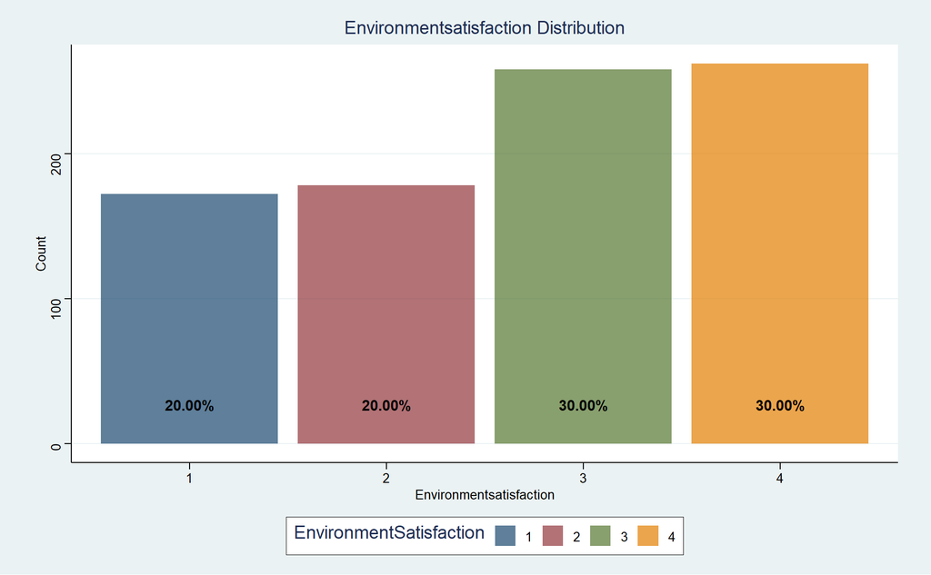

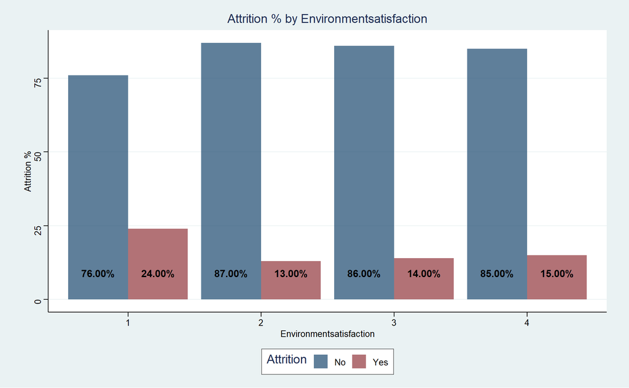

```r
bar_plot_check(EnvironmentSatisfaction, Attrition)
```

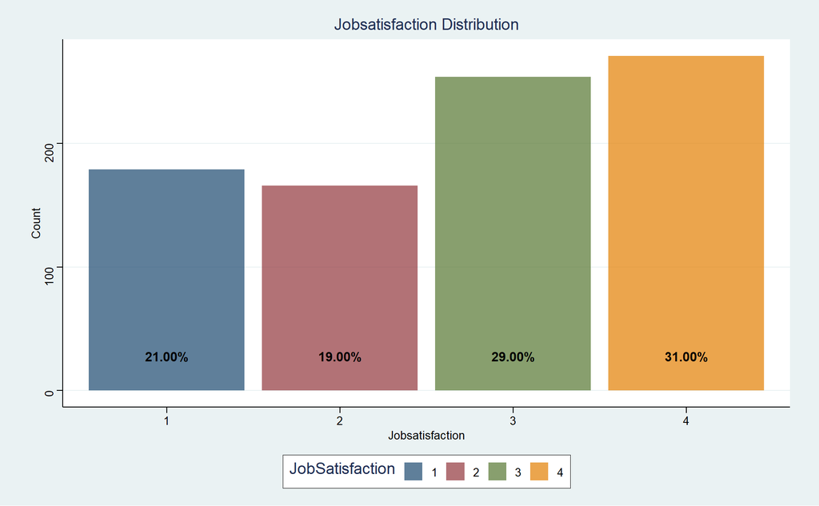

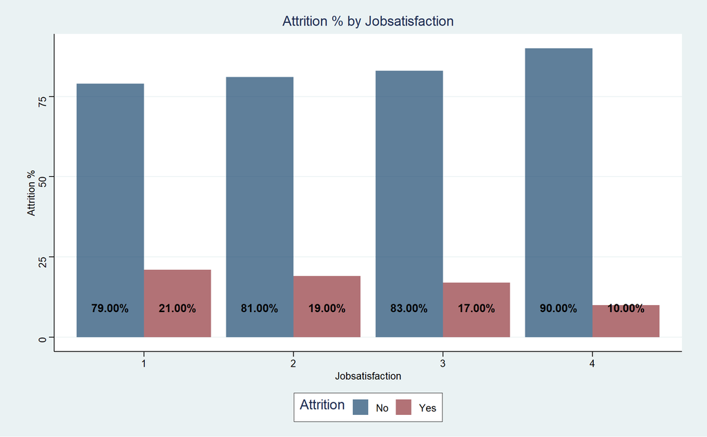

```r
bar_plot_check(JobSatisfaction, Attrition)
```

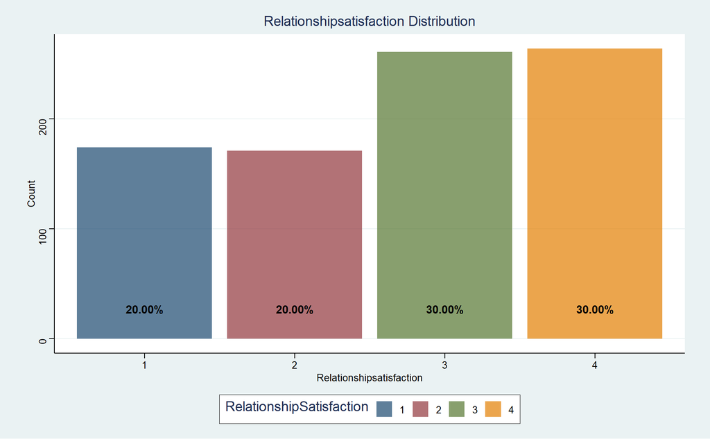

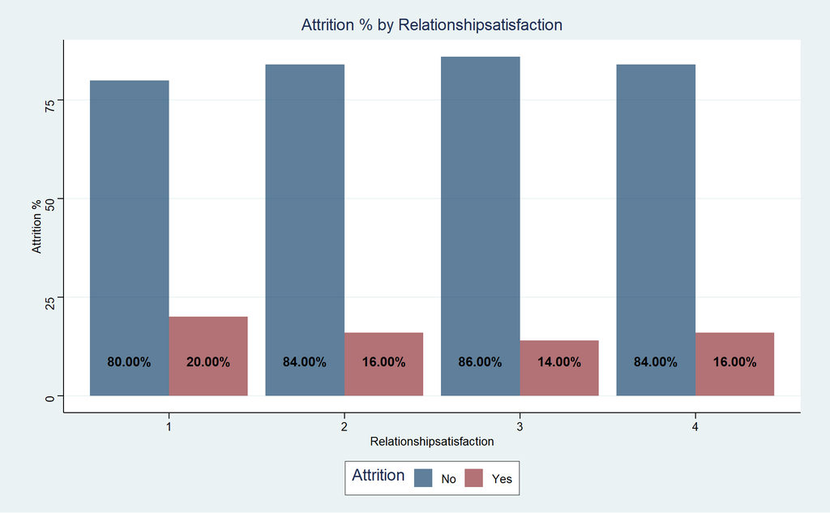

```r
bar_plot_check(RelationshipSatisfaction, Attrition)
```

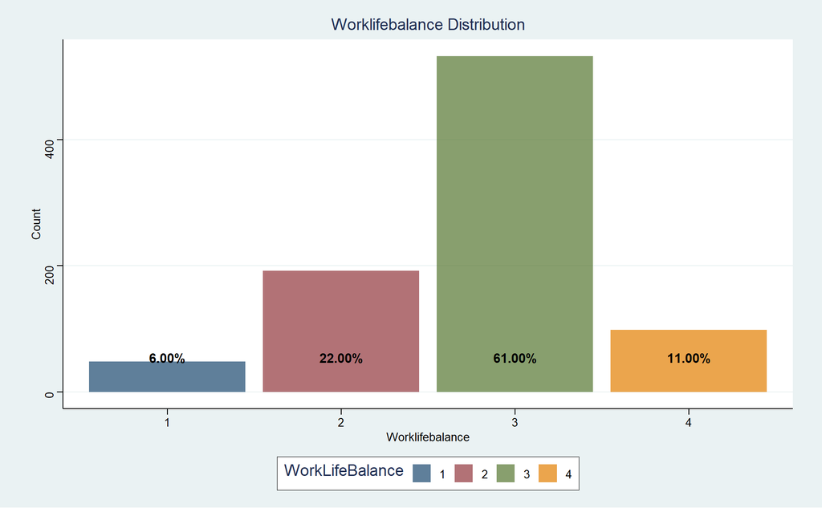

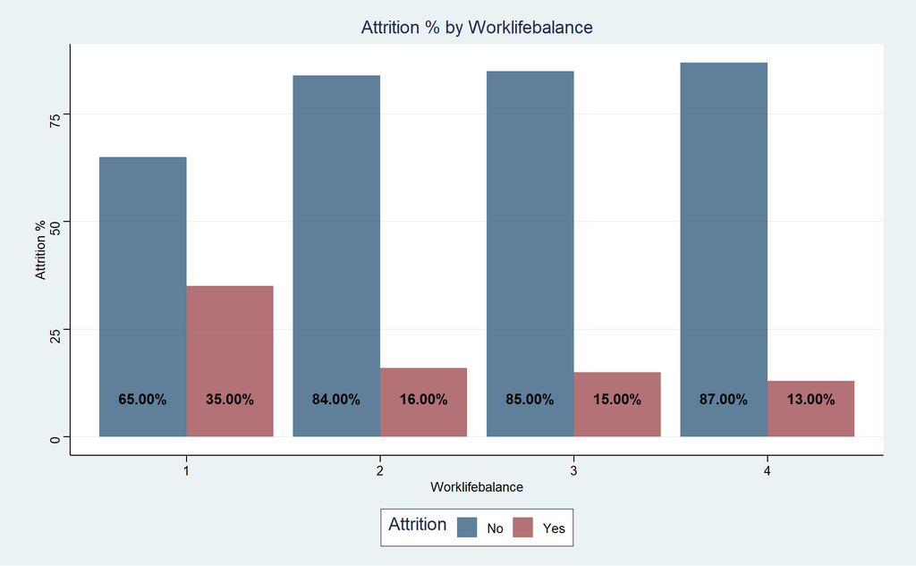

```r
bar_plot_check(WorkLifeBalance, Attrition)
```

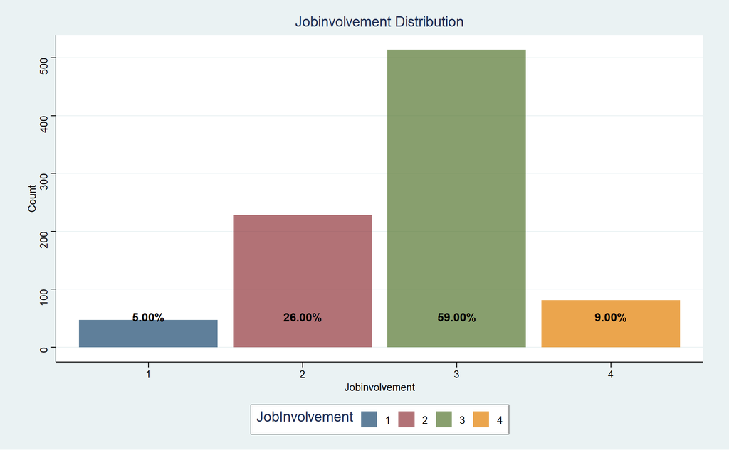

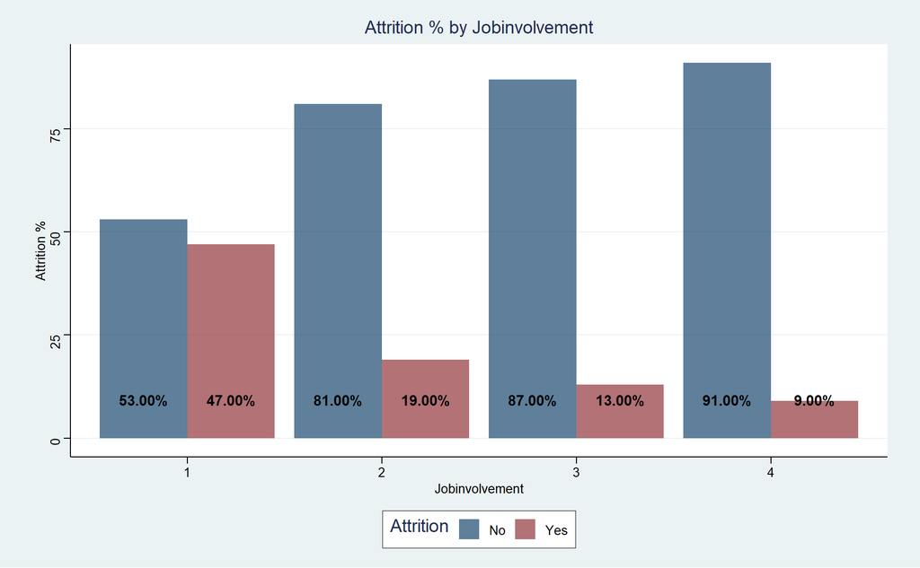

```r
bar_plot_check(JobInvolvement, Attrition)
```

### Time Variables

- More time with current manager correlated with less attrition, probably related with both manager and job satisfaction.
- Time since last promotion does not have any strong visual trends.
- Years in current role and years spent at company correlated with less attrition, similar to time with current manager
- More variance in number of companies worked for those who quit, probably related to age of employees with higher turnover but who also haven’t had experience to be at more than 1 company.

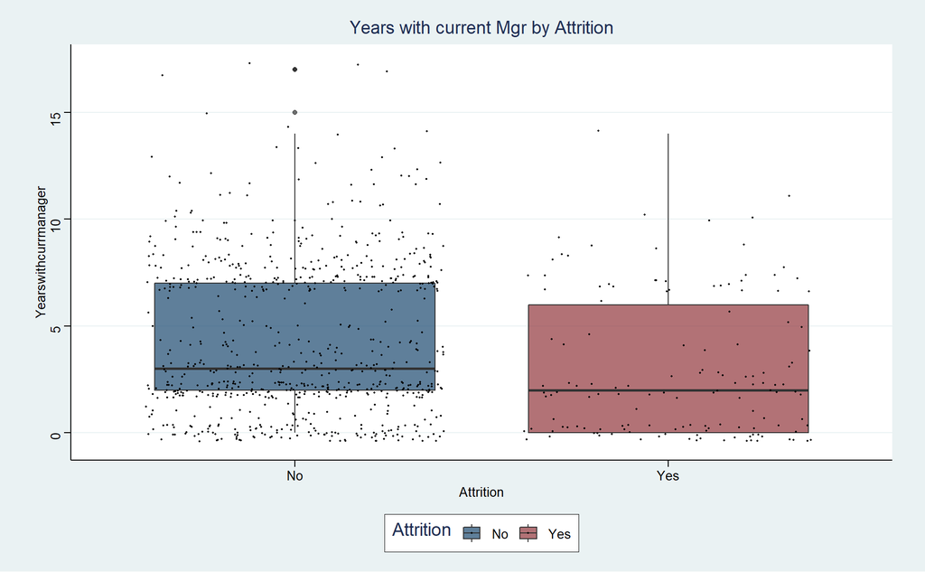

```r
box_plot_check(YearsWithCurrManager, Attrition, "Years with current Mgr by Attrition")
```

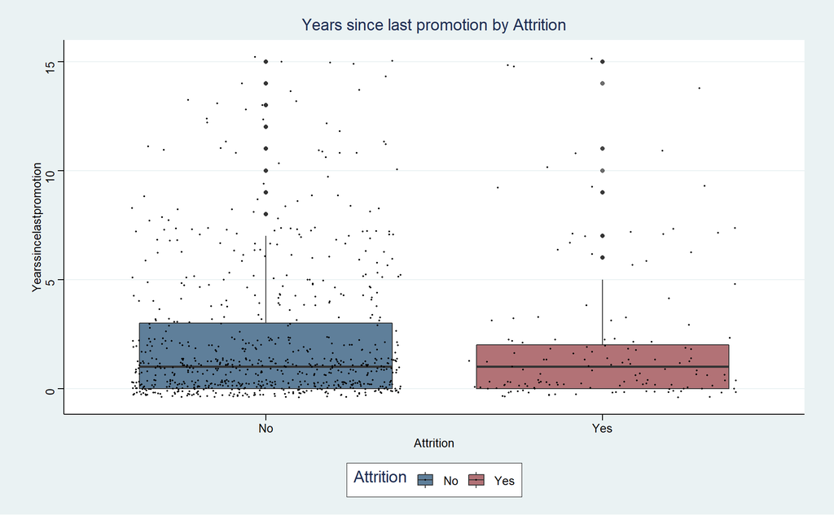

```r
box_plot_check(YearsSinceLastPromotion, Attrition, "Years since last promotion by Attrition")
```

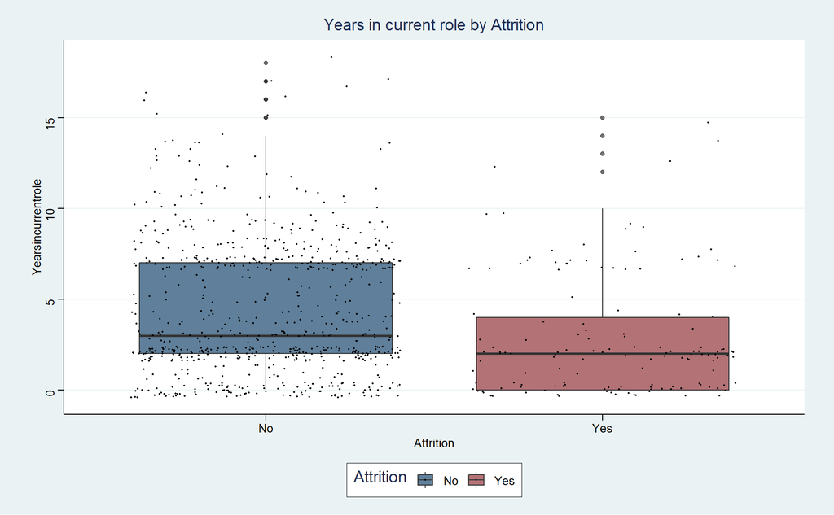

```r
box_plot_check(YearsInCurrentRole, Attrition, "Years in current role by Attrition")
```

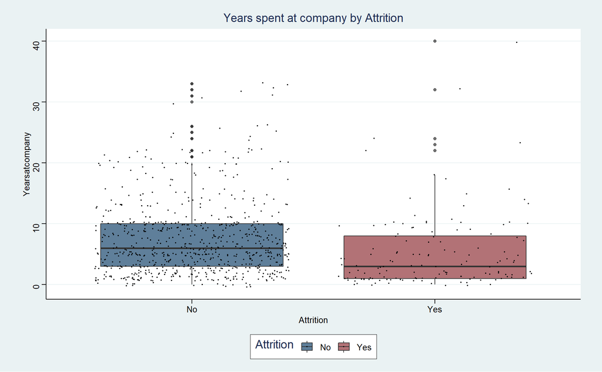

```r
box_plot_check(YearsAtCompany, Attrition, "Years spent at company by Attrition")
```

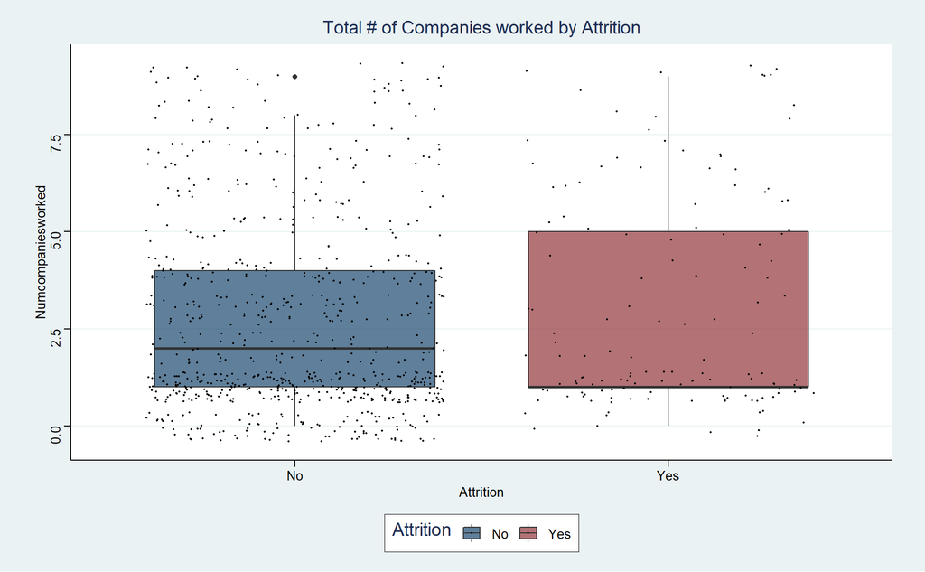

```r
box_plot_check(NumCompaniesWorked, Attrition, "Total # of Companies worked by Attrition")
```

### Other Variables

- Most employees at level 0 or 1. Interestingly highest turnover occurs at 0 (expected) but also at the highest level 3.
- Not a strong difference in the only two levels found of performance rating (3 and 4).
- Non-exempt employees (overtime = yes) with triple the turnover than exempt.

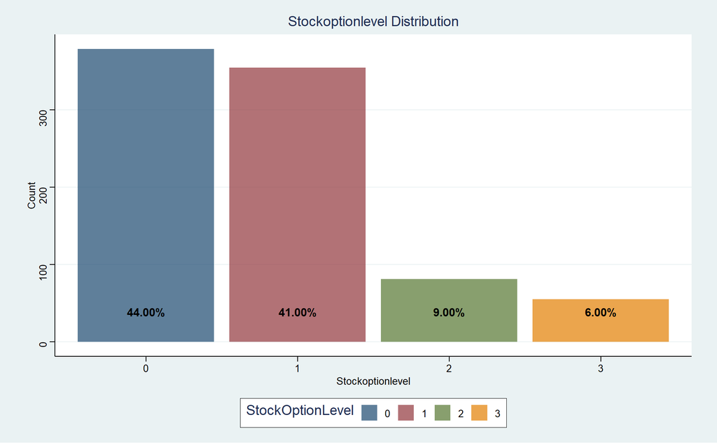

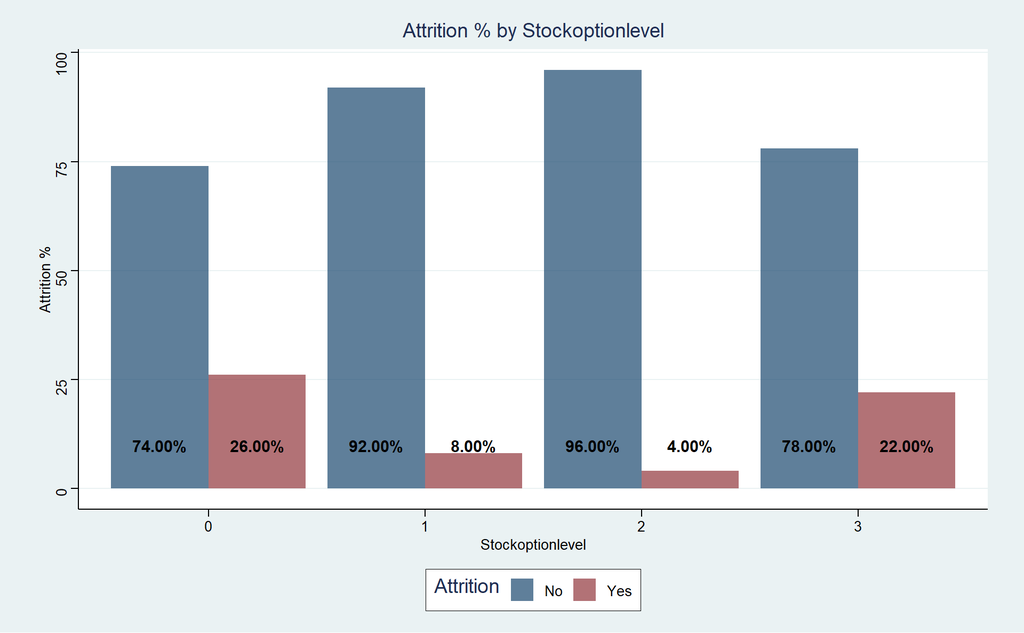

```r
bar_plot_check(StockOptionLevel, Attrition)
```

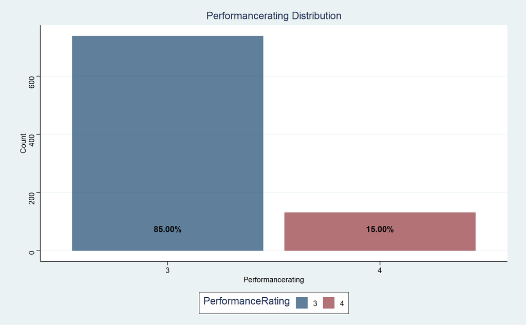

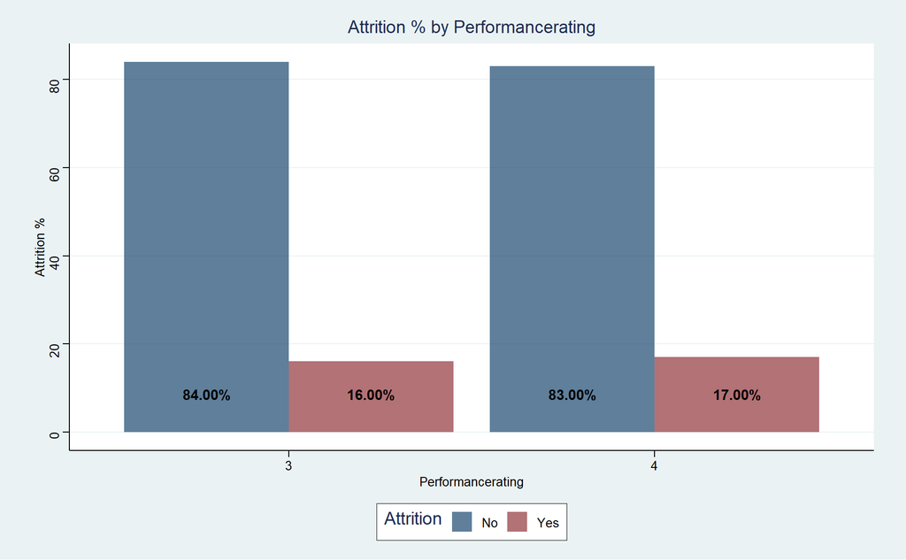

```r
bar_plot_check(PerformanceRating, Attrition)
```

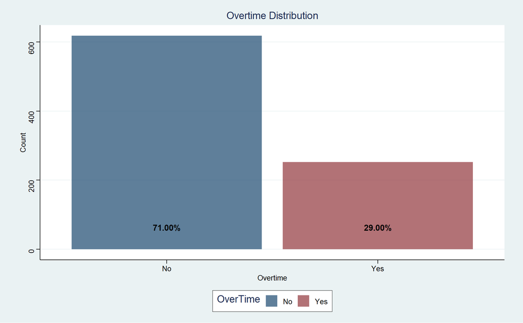

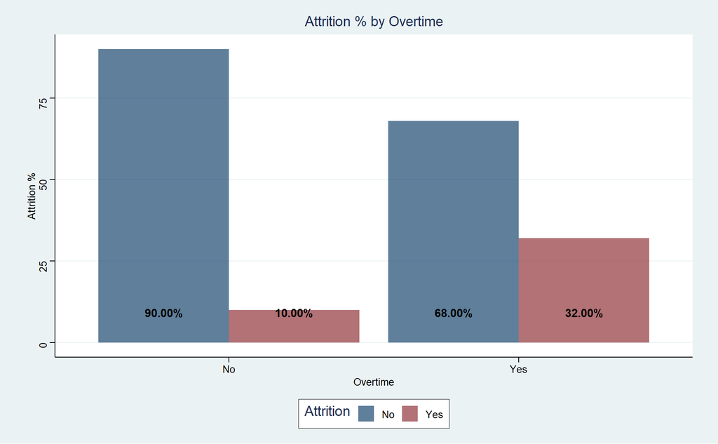

```r
bar_plot_check(OverTime, Attrition)
```

### Monthly Income Relationships

- By Department
  - Sales have highest median income
  - R&D have highest incomes observed
  - HR has most variation but also lowest median
- By Job Level
  - Each job level is correlated with an increase in income, as expected
- Attrition Significance
  - P value < .001 that log Monthly Income is different between those who stay and leave

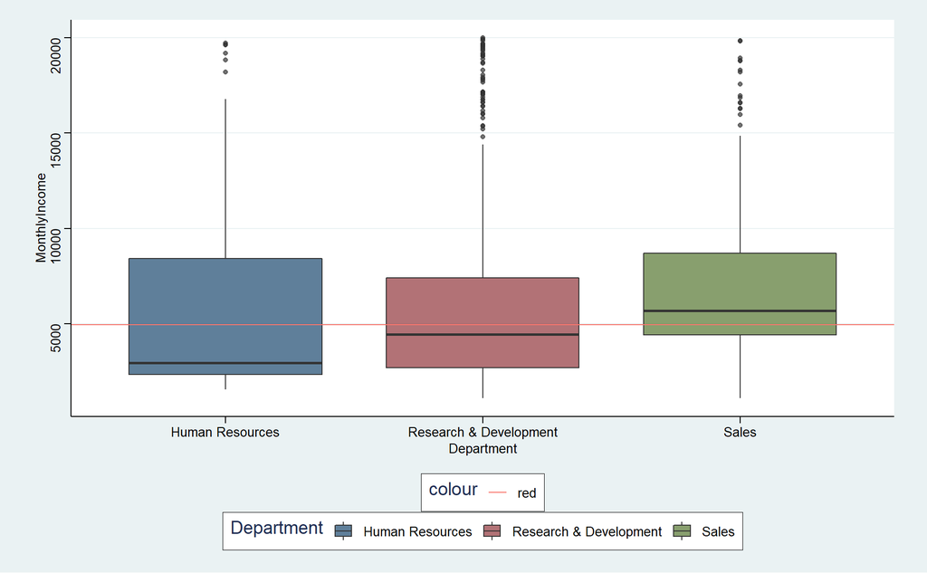

```r
hrdf %>% ggplot(aes(x = Department, y = MonthlyIncome, fill = Department)) +
  geom_boxplot(alpha = .7) + geom_hline(aes(yintercept = median(MonthlyIncome), color = 'red')) +
  theme_stata() + scale_fill_stata()
```

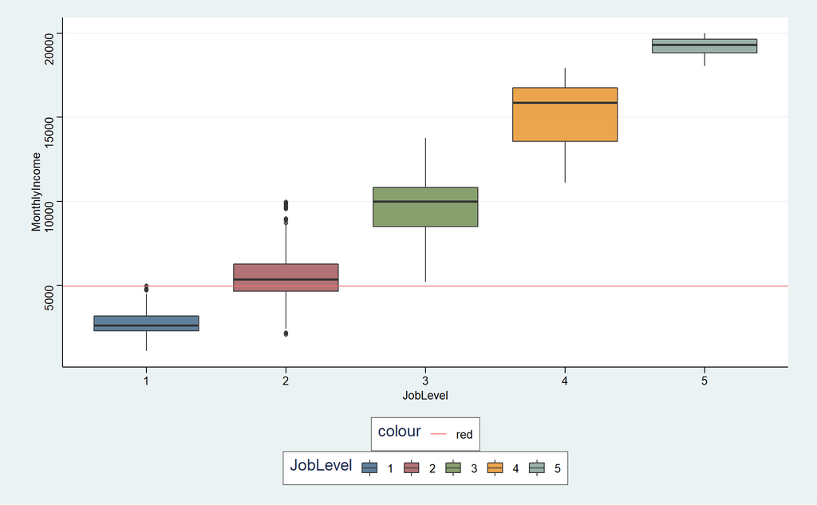

```r
hrdf %>% ggplot(aes(x = JobLevel, y = MonthlyIncome, fill = JobLevel)) +
  geom_boxplot(alpha = .7) + geom_hline(aes(yintercept = median(MonthlyIncome), color = 'red')) +
  theme_stata() + scale_fill_stata()
```

```r
hrdf$logIncome <- log(hrdf$MonthlyIncome)
t.test(logIncome ~ Attrition, data = hrdf)
```

```
##
##  Welch Two Sample t-test
##
## data:  logIncome by Attrition
## t = 5.9593, df = 195.72, p-value = 1.16e-08
## alternative hypothesis: true difference in means between group No and group Yes is not equal to 0
## 95 percent confidence interval:
##  0.2391013 0.4756331
## sample estimates:
##  mean in group No mean in group Yes
##          8.595187          8.237820
```

### Correlation Check

- Nothing too unexpected
- Total Working Years strong correlation with Monthly Income, Age, and other “time” variables
- “Rate” variables not strongly correlated, as mentioned earlier

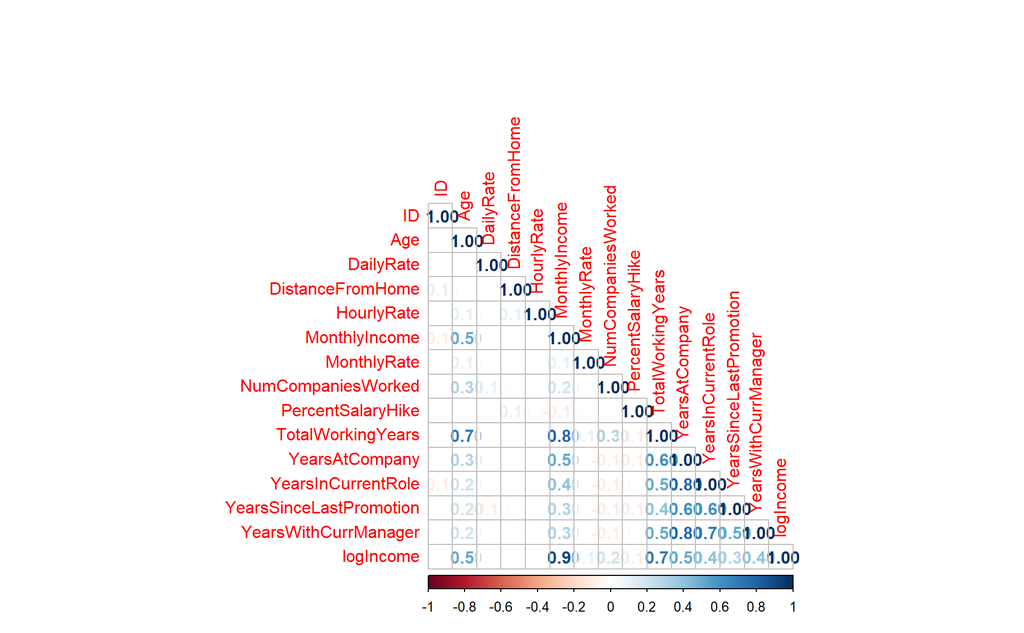

```r
#cor testing
nums <- select_if(hrdf, is.numeric)

corr <- round(cor(nums), 1)

corrplot(corr,
           type = "lower",
           method="number")
```

# Attrition Prediction:

## KNN

### Feature Selection

- The following variables were removed for redundancy or lack of usefullness:
  - ID
  - Age
  - Education
- The following variables were removed due to lack of explainability/trust in data:
  - HourlyRate
  - DailyRate
  - MonthlyRate

### Feature Manipulation

The data was centered and scaled. The scaling is particularly important for Income, as otherwise it could be at risk of being overly weighted in importance.

### Method and Results

- Repeated K-fold cross validation was used, with 75% data splits and 100 repetitions of 5 folds.
- The model was set at maximizing specificity, as this is the hardest variable to maximize here, and potentially the most important (identifying attrition risks that retention efforts could be spent on)
- Sensitivity (correctly prediction no attrition) of 88% was achieved
- Specificity (correct predictions of attrition) of 80% was achieved.

```r
set.seed(44)

cleandf <- subset(hrdf, select = -c(DailyRate, HourlyRate, MonthlyRate, ID, Age, Education))

# control settings for KNN
# NOTE: needed in order to focus on specificity

train.knn <- trainControl(
  method = "repeatedcv",
  number = 5,
  repeats = 100,
  summaryFunction = twoClassSummary,
  classProbs = TRUE,
  p = .75
)

# KNN on Training Set

attrition.knn <- train(
  Attrition ~ .,
  data = cleandf,
  method = "knn",
  metric = "Spec",
  trControl = train.knn,
  preProcess = c("center","scale"),
  tuneLength = 6
)

# Adding predictions to df
cleandf$KNN_Pred <- predict(attrition.knn, newdata = cleandf)
# creating confusion matrix
confusionMatrix(table(cleandf$Attrition, cleandf$KNN_Pred))
```

```
## Confusion Matrix and Statistics
##
##
##        No Yes
##   No  720  10
##   Yes 101  39
##
##                Accuracy : 0.8724
##                  95% CI : (0.8484, 0.8939)
##     No Information Rate : 0.9437
##     P-Value [Acc > NIR] : 1
##
##                   Kappa : 0.3592
##
##  Mcnemar's Test P-Value : <2e-16
##
##             Sensitivity : 0.8770
##             Specificity : 0.7959
##          Pos Pred Value : 0.9863
##          Neg Pred Value : 0.2786
##              Prevalence : 0.9437
##          Detection Rate : 0.8276
##    Detection Prevalence : 0.8391
##       Balanced Accuracy : 0.8364
##
##        'Positive' Class : No
##
```

## Naive-Bayes

### Feature Selection

- The same variables used with the KNN were used here for similar assumptions

### Feature Manipulation

Monthly Income was replaced with the log of Monthly Income to help get closer to a normal distribution.

### Method and Results

```r
cleandf$logIncome <- log(cleandf$MonthlyIncome)

cleandf2 <- subset(cleandf,select = -c(KNN_Pred, MonthlyIncome))

iterations = 100
masterAcc = matrix(nrow = iterations)
masterSens = matrix(nrow = iterations)
masterSpec = matrix(nrow = iterations)

for(j in 1:iterations)
{

  trainIndices = sample(seq(1:length(cleandf2$Attrition)),round(.75*length(cleandf2$Attrition)))
  trainNaive = cleandf2[trainIndices,]
  testNaive = cleandf2[-trainIndices,]

  model = naiveBayes(trainNaive[,-1], trainNaive$Attrition)
  CM = confusionMatrix(table(predict(model,testNaive[,-1]), testNaive$Attrition))
  masterAcc[j] = CM$overall[1]
  masterSens[j] = CM$byClass[1]
  masterSpec[j] = CM$byClass[2]
}

MeanAcc = colMeans(masterAcc)
MeanSens <- colMeans(masterSens)
MeanSpec <- colMeans(masterSpec)

MeanAcc
```

```
## [1] 0.8271101
```

```r
MeanSens
```

```
## [1] 0.8734859
```

```r
MeanSpec
```

```
## [1] 0.584064
```

# Monthly Income Prediction:

## Linear Regression

### Feature Manipulation

No further manipulation was needed. The residual plots and QQ plots looked good for assumptions of linearity. There is some caution of departure from normality at the upper level of incomes, where we have seen data to be the most skewed and present of outliers. Log fitting for income did not help improve this fit.

### Method and Results

- The four variables mentioned above were able to predict Monthly Income with an RMSE of only $993.
- Variables ordered by importance based off test statistics:
  - Job Level
  - Job Role
  - Total Working Years
  - Business Travel
- An Adjusted R squared of .95 infers that 95% of the variability in Monthly Income can be explained by these 4 variables.

```r
cleandf3 <- subset(cleandf,select = -c(KNN_Pred))

fit <- lm(MonthlyIncome ~ ., data = cleandf3)
summary(fit)
```

```
##
## Call:
## lm(formula = MonthlyIncome ~ ., data = cleandf3)
##
## Residuals:
##      Min       1Q   Median       3Q      Max
## -1609.14  -278.32   -54.94   217.71  1941.26
##
## Coefficients:
##                                    Estimate Std. Error t value Pr(>|t|)
## (Intercept)                      -2.992e+04  7.068e+02 -42.333  < 2e-16 ***
## AttritionYes                      1.518e+02  5.595e+01   2.713  0.00681 **
## BusinessTravelTravel_Frequently  -4.306e+01  6.599e+01  -0.653  0.51423
## BusinessTravelTravel_Rarely       1.786e-01  5.599e+01   0.003  0.99746
## DepartmentResearch & Development  1.128e+02  2.231e+02   0.505  0.61347
## DepartmentSales                  -2.226e+02  2.298e+02  -0.969  0.33305
## DistanceFromHome                 -3.314e+00  2.127e+00  -1.558  0.11960
## EducationFieldLife Sciences       5.810e+00  1.713e+02   0.034  0.97296
## EducationFieldMarketing          -2.221e+01  1.823e+02  -0.122  0.90306
## EducationFieldMedical            -3.028e+01  1.719e+02  -0.176  0.86018
## EducationFieldOther              -6.359e+01  1.835e+02  -0.347  0.72902
## EducationFieldTechnical Degree    4.903e+01  1.783e+02   0.275  0.78334
## EnvironmentSatisfaction2          7.743e+01  5.406e+01   1.432  0.15244
## EnvironmentSatisfaction3          9.310e+01  5.005e+01   1.860  0.06322 .
## EnvironmentSatisfaction4          1.176e+02  4.990e+01   2.356  0.01871 *
## GenderMale                        3.708e+01  3.450e+01   1.075  0.28285
## JobInvolvement2                  -9.098e+01  8.081e+01  -1.126  0.26057
## JobInvolvement3                  -7.770e+01  7.791e+01  -0.997  0.31895
## JobInvolvement4                  -1.296e+02  9.422e+01  -1.375  0.16947
## JobLevel2                        -2.631e+02  8.018e+01  -3.281  0.00108 **
## JobLevel3                         1.102e+03  1.191e+02   9.247  < 2e-16 ***
## JobLevel4                         3.517e+03  1.680e+02  20.927  < 2e-16 ***
## JobLevel5                         5.653e+03  1.958e+02  28.872  < 2e-16 ***
## JobRoleHuman Resources           -2.917e+01  2.427e+02  -0.120  0.90436
## JobRoleLaboratory Technician     -1.774e+02  8.947e+01  -1.983  0.04772 *
## JobRoleManager                    2.419e+03  1.415e+02  17.089  < 2e-16 ***
## JobRoleManufacturing Director     9.994e+01  7.920e+01   1.262  0.20739
## JobRoleResearch Director          2.352e+03  1.089e+02  21.590  < 2e-16 ***
## JobRoleResearch Scientist        -1.737e+02  9.011e+01  -1.927  0.05428 .
## JobRoleSales Executive            3.722e+02  1.672e+02   2.226  0.02631 *
```

[output cut: 28 more lines]

```
## YearsSinceLastPromotion           6.913e+00  7.184e+00   0.962  0.33623
## YearsWithCurrManager             -1.241e+01  7.874e+00  -1.577  0.11530
## GroupEducation2                  -2.176e+01  6.431e+01  -0.338  0.73525
## GroupEducation3                   2.979e+01  5.950e+01   0.501  0.61671
## GroupEducation4+                  1.066e+00  6.344e+01   0.017  0.98660
## GroupAge26-35                    -1.715e+02  7.073e+01  -2.425  0.01553 *
## GroupAge35-45                    -1.314e+02  7.805e+01  -1.684  0.09257 .
## GroupAge46+                      -2.159e+02  9.237e+01  -2.338  0.01963 *
## logIncome                         4.133e+03  7.952e+01  51.971  < 2e-16 ***
## ---
## Signif. codes:  0 '***' 0.001 '**' 0.01 '*' 0.05 '.' 0.1 ' ' 1
##
## Residual standard error: 484.8 on 803 degrees of freedom
## Multiple R-squared:  0.9897, Adjusted R-squared:  0.9889
## F-statistic:  1172 on 66 and 803 DF,  p-value: < 2.2e-16
```

```r
fit2 <- lm(MonthlyIncome ~ TotalWorkingYears + JobRole + JobLevel + BusinessTravel, data = cleandf3)

summary(fit2)
```

```
##
## Call:
## lm(formula = MonthlyIncome ~ TotalWorkingYears + JobRole + JobLevel +
##     BusinessTravel, data = cleandf3)
##
## Residuals:
##     Min      1Q  Median      3Q     Max
## -3110.3  -623.3   -90.3   598.8  4210.7
##
## Coefficients:
##                                  Estimate Std. Error t value Pr(>|t|)
## (Intercept)                      3347.049    203.862  16.418  < 2e-16 ***
## TotalWorkingYears                  45.526      7.737   5.884 5.74e-09 ***
## JobRoleHuman Resources          -1120.078    251.673  -4.451 9.70e-06 ***
## JobRoleLaboratory Technician    -1237.810    174.790  -7.082 2.98e-12 ***
## JobRoleManager                   3339.213    237.087  14.084  < 2e-16 ***
## JobRoleManufacturing Director     111.267    158.004   0.704  0.48150
## JobRoleResearch Director         3479.374    210.732  16.511  < 2e-16 ***
## JobRoleResearch Scientist       -1032.180    178.038  -5.798 9.47e-09 ***
## JobRoleSales Executive            -17.421    136.241  -0.128  0.89828
## JobRoleSales Representative     -1248.290    220.737  -5.655 2.12e-08 ***
## JobLevel2                        1713.167    138.793  12.343  < 2e-16 ***
## JobLevel3                        4938.935    186.471  26.486  < 2e-16 ***
## JobLevel4                        8264.478    281.610  29.347  < 2e-16 ***
## JobLevel5                       10978.369    331.313  33.136  < 2e-16 ***
## BusinessTravelTravel_Frequently   179.511    131.953   1.360  0.17406
## BusinessTravelTravel_Rarely       327.375    111.836   2.927  0.00351 **
## ---
## Signif. codes:  0 '***' 0.001 '**' 0.01 '*' 0.05 '.' 0.1 ' ' 1
##
## Residual standard error: 1003 on 854 degrees of freedom
## Multiple R-squared:  0.9533, Adjusted R-squared:  0.9524
## F-statistic:  1161 on 15 and 854 DF,  p-value: < 2.2e-16
```

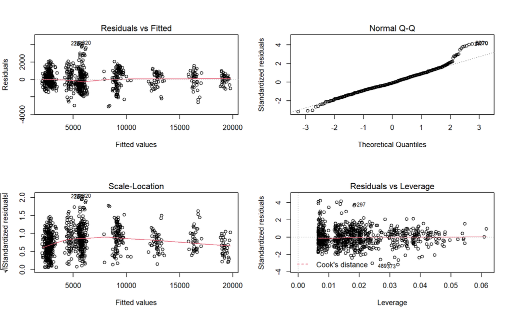

```r
#check assumptions, violation of normality at upper bounds, otherwise great
par(mfrow = c(2, 2))
plot(fit2)
```

```r
#calculate RMSE
sqrt(mean(fit2$residuals^2))
```

```
## [1] 993.3473
```

# Conclusion:

#### Based on these insights we have the following recommendations that Frito-Lay can explore in further detail:

1. A follow up investigation is necessary to understand what is leading to the high turnover for some job roles, particularly Sales Rep, and what can be done to improve retention.
2. Focus on general retention strategies for younger employees - an authentically ethical and inclusive company culture, work life balance flexibility, and skill growth tend to be rated as more important for this age group compared to others (https://hbr.org/2020/06/what-your-youngest-employees-need-most-right-now, data trends from Pew Research Center).
3. Income is a strong predictor of turnover as well, it could be worth looking into better identifying top performers and making sure that their Job Level and potentially Role/Title can be improved as necessary, without being as restricted by age or total experience.
4. The KNN model can be used to identify employees that could potentially be at a higher risk of turnover to focus efforts on.